# Vaccination Data Analysis

## Facebook prophet model

```r
#newvac<-read_csv("vac.csv",show_col_types = FALSE)
#newcases<-read_csv("cases.csv",show_col_types = FALSE)
library("dplyr")
library("prophet")
```

```r
library("ggplot2")
library("tsbox")
fb_frame = newCasesIndia
fb_frame$floor <- 0

# Facebook prophet model expects columns to be with specific names.
colnames(fb_frame) <- c("ds", "y","floor")

#fb_frame = rename(fb_frame, c(ds="newCases.date", y="newCases.India"))

# Split dataset into train and test set.
fb_train = fb_frame[1:length(fb_frame)-30,]
fb_test = fb_frame[length(fb_frame)-30:length(fb_frame),]

m <- prophet(df=fb_frame,growth = "linear",seasonality.mode = "additive", seasonality.prior.scale =10,yearly.seasonality=TRUE,changepoint.prior.scale = 0.05)
```

```
## Disabling daily seasonality. Run prophet with daily.seasonality=TRUE to override this.
```

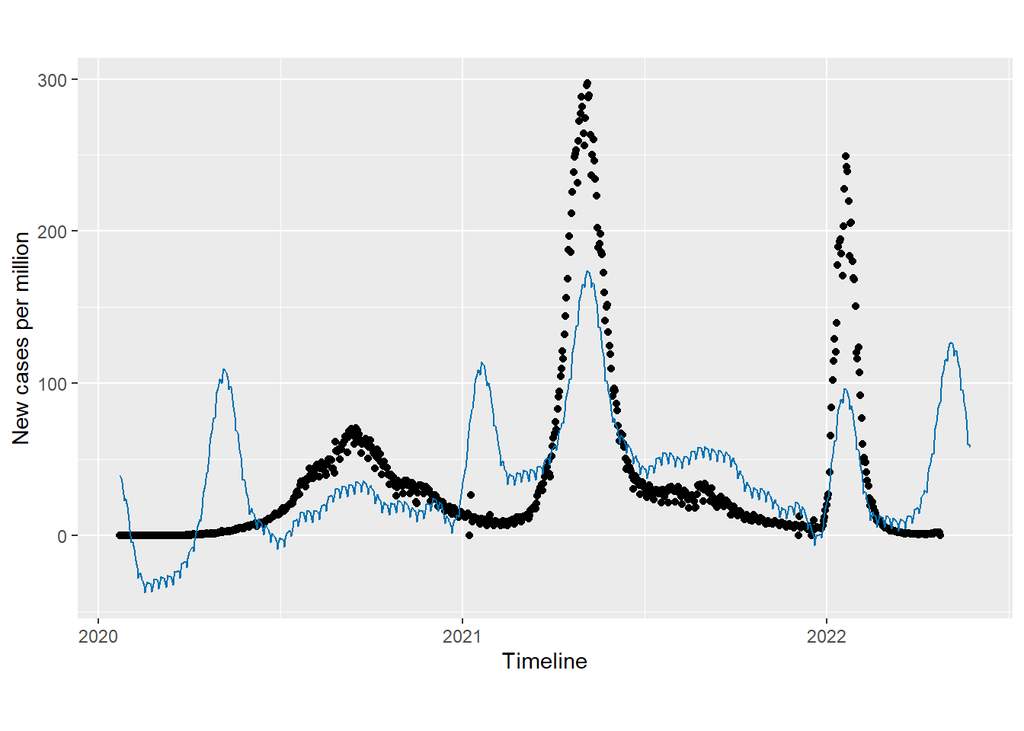

```r
#multiplicative seems overfitting

future = make_future_dataframe(m, periods = 30)
future$floor <- 0

fb_forecast = predict(m, future)
fb_forecast1 = fb_forecast[c('ds','yhat')]

plot(m, fb_forecast1, xlab = "Timeline",ylab = "New cases per million")
```

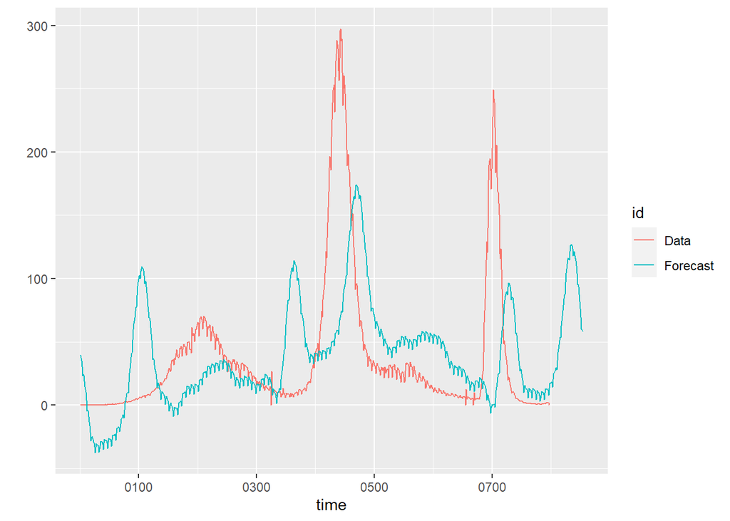

```r
# Plot forecast and test set.
ts_ggplot(Forecast=ts(fb_forecast1$yhat), Data=ts(fb_test$y))
```

```r
tail(fb_forecast1)
```

```
##             ds     yhat
## 849 2022-05-20 81.91862
## 850 2022-05-21 76.55245
## 851 2022-05-22 69.45658
## 852 2022-05-23 59.94541
## 853 2022-05-24 59.72447
## 854 2022-05-25 57.96887
```

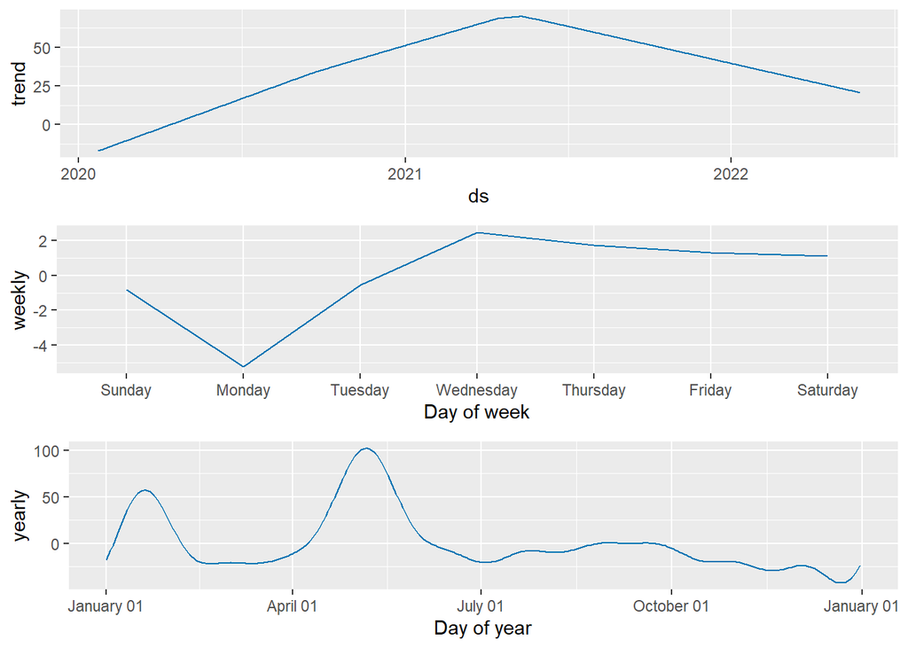

```r
# Plotting forecast components.
prophet_plot_components(m, fb_forecast)
```

```r
#verifydf<-data.frame(fb_forecast$ds,fb_forecast$yhat,fb_frame$y[1:280])
```

## Smoothing Predictions in R for 30 days

```r
library(tidyverse)
library(fpp2)
library(forecast)

data = newCasesIndia$newCases.India

data.train = window(data,end = floor(length(data)*0.88))
data.test  = window(data,start = ceiling(length(data)*0.88))

holt.data <- holt(data.train,h = 30)
ses.data <- ses(data.train,h = 30)
tbats.data<- forecast(tbats(data.train), h = 30)

summary(ses.data)
```

```
##
## Forecast method: Simple exponential smoothing
##
## Model Information:
## Simple exponential smoothing
##
## Call:
##  ses(y = data.train, h = 30)
##
##   Smoothing parameters:
##     alpha = 0.9999
##
##   Initial states:
##     l = -0.1247
##
##   sigma:  5.4318
##
##      AIC     AICc      BIC
## 7232.765 7232.798 7246.523
##
## Error measures:
##                     ME     RMSE      MAE MPE MAPE      MASE      ACF1
## Training set 0.2556762 5.424306 2.972927 NaN  Inf 0.9986989 0.2208649
##
## Forecasts:
##     Point Forecast    Lo 80    Hi 80    Lo 95    Hi 95
## 726       185.2219 178.2608 192.1831 174.5758 195.8681
## 727       185.2219 175.3779 195.0660 170.1668 200.2771
## 728       185.2219 173.1657 197.2782 166.7835 203.6604
## 729       185.2219 171.3007 199.1432 163.9313 206.5126
## 730       185.2219 169.6576 200.7863 161.4184 209.0255
## 731       185.2219 168.1721 202.2718 159.1465 211.2974
## 732       185.2219 166.8061 203.6378 157.0573 213.3866
## 733       185.2219 165.5346 204.9093 155.1127 215.3311
## 734       185.2219 164.3404 206.1035 153.2864 217.1575
## 735       185.2219 163.2109 207.2330 151.5589 218.8850
## 736       185.2219 162.1366 208.3073 149.9159 220.5280
## 737       185.2219 161.1101 209.3338 148.3460 222.0979
## 738       185.2219 160.1255 210.3184 146.8403 223.6036
## 739       185.2219 159.1782 211.2657 145.3914 225.0524
## 740       185.2219 158.2641 212.1798 143.9935 226.4504
## 741       185.2219 157.3800 213.0639 142.6414 227.8025
## 742       185.2219 156.5231 213.9207 141.3309 229.1130
## 743       185.2219 155.6911 214.7528 140.0585 230.3854
## 744       185.2219 154.8819 215.5620 138.8209 231.6230
## 745       185.2219 154.0938 216.3501 137.6155 232.8284
## 746       185.2219 153.3250 217.1188 136.4398 234.0040
## 747       185.2219 152.5744 217.8694 135.2919 235.1520
## 748       185.2219 151.8407 218.6032 134.1697 236.2741
## 749       185.2219 151.1227 219.3211 133.0717 237.3722
## 750       185.2219 150.4196 220.0243 131.9964 238.4475
## 751       185.2219 149.7304 220.7135 130.9423 239.5016
## 752       185.2219 149.0543 221.3896 129.9083 240.5356
## 753       185.2219 148.3906 222.0533 128.8933 241.5506
## 754       185.2219 147.7387 222.7052 127.8963 242.5476
## 755       185.2219 147.0979 223.3460 126.9163 243.5276
```

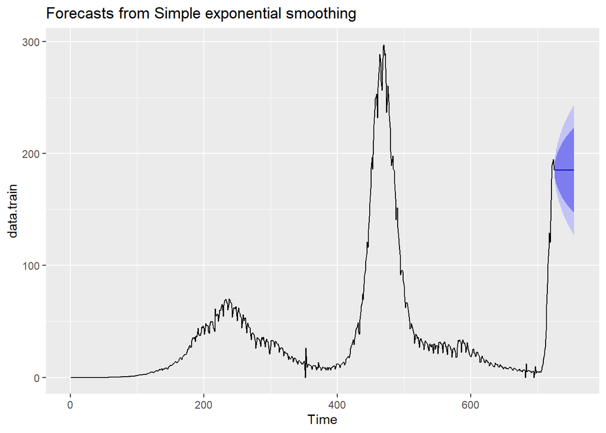

```r
autoplot(ses.data)
```

```r
summary(holt.data)
```

```
##
## Forecast method: Holt's method
##
## Model Information:
## Holt's method
##
## Call:
##  holt(y = data.train, h = 30)
##
##   Smoothing parameters:
##     alpha = 0.9999
##     beta  = 0.1105
##
##   Initial states:
##     l = 0.0016
##     b = -0.3554
##
##   sigma:  5.1549
##
##      AIC     AICc      BIC
## 7158.881 7158.964 7181.812
##
## Error measures:
##                     ME     RMSE      MAE MPE MAPE      MASE       ACF1
## Training set 0.1015798 5.140635 2.830943 NaN  Inf 0.9510023 0.02731011
##
## Forecasts:
##     Point Forecast    Lo 80    Hi 80    Lo 95    Hi 95
## 726       193.0081 186.4018 199.6143 182.9047 203.1114
## 727       200.7932 190.9212 210.6652 185.6953 215.8911
## 728       208.5783 195.8301 221.3266 189.0816 228.0751
## 729       216.3635 200.8750 231.8519 192.6759 240.0510
## 730       224.1486 205.9649 242.3323 196.3390 251.9582
## 731       231.9337 211.0567 252.8107 200.0051 263.8623
## 732       239.7189 216.1273 263.3104 203.6387 275.7991
## 733       247.5040 221.1628 273.8451 207.2187 287.7893
## 734       255.2891 226.1550 284.4232 210.7324 299.8459
## 735       263.0742 231.0985 295.0500 214.1716 311.9769
## 736       270.8594 235.9899 305.7288 217.5312 324.1876
## 737       278.6445 240.8271 316.4619 220.8078 336.4812
## 738       286.4296 245.6088 327.2505 223.9995 348.8598
## 739       294.2148 250.3342 338.0954 227.1052 361.3244
## 740       301.9999 255.0029 348.9969 230.1242 373.8757
## 741       309.7850 259.6149 359.9552 233.0564 386.5137
## 742       317.5702 264.1703 370.9700 235.9021 399.2382
## 743       325.3553 268.6694 382.0412 238.6617 412.0489
## 744       333.1404 273.1126 393.1683 241.3357 424.9451
## 745       340.9256 277.5002 404.3509 243.9248 437.9263
## 746       348.7107 281.8328 415.5886 246.4297 450.9916
## 747       356.4958 286.1109 426.8808 248.8513 464.1403
## 748       364.2810 290.3350 438.2269 251.1903 477.3716
## 749       372.0661 294.5057 449.6265 253.4477 490.6845
## 750       379.8512 298.6236 461.0789 255.6242 504.0782
## 751       387.6364 302.6892 472.5836 257.7208 517.5519
## 752       395.4215 306.7030 484.1399 259.7383 531.1046
## 753       403.2066 310.6658 495.7475 261.6776 544.7356
## 754       410.9917 314.5779 507.4056 263.5395 558.4440
## 755       418.7769 318.4400 519.1138 265.3248 572.2289
```

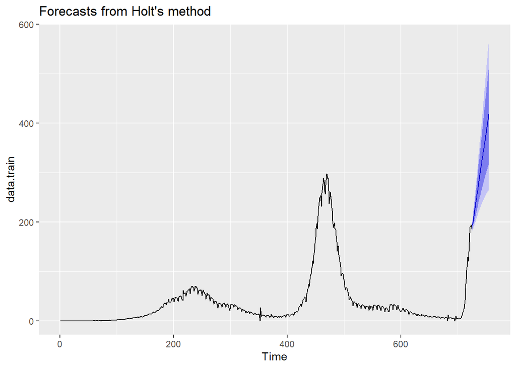

```r
autoplot(holt.data)
```

```r
summary(tbats.data)
```

```
##
## Forecast method: BATS(1, {0,2}, 0.802, -)
##
## Model Information:
## BATS(1, {0,2}, 0.802, -)
##
## Call: tbats(y = data.train)
##
## Parameters
##   Alpha: -0.1549889
##   Beta: 0.3306189
##   Damping Parameter: 0.80219
##   MA coefficients: 0.875607 0.373079
##
## Seed States:
##               [,1]
## [1,] -0.0115960827
## [2,]  0.0001059042
## [3,]  0.0000000000
## [4,]  0.0000000000
##
## Sigma: 4.704712
## AIC: 7038.393
##
## Error measures:
##                      ME     RMSE      MAE MPE MAPE      MASE       ACF1
## Training set 0.09402016 4.704712 2.666969 NaN  Inf 0.8959183 0.01434157
##
## Forecasts:
##     Point Forecast    Lo 80    Hi 80     Lo 95    Hi 95
## 726       191.5158 185.4865 197.5451 182.29473 200.7369
## 727       199.7592 191.2926 208.2258 186.81066 212.7077
## 728       202.2109 192.4888 211.9331 187.34223 217.0796
## 729       198.1629 187.2625 209.0634 181.49213 214.8337
## 730       194.9157 181.8879 207.9434 174.99144 214.8399
## 731       192.3108 176.5312 208.0903 168.17800 216.4435
## 732       190.2211 171.3651 209.0771 161.38338 219.0589
## 733       188.5448 166.4791 210.6106 154.79817 222.2915
## 734       187.2001 161.9017 212.4986 148.50951 225.8907
## 735       186.1214 157.6295 214.6133 142.54681 229.6960
## 736       185.2561 153.6442 216.8680 136.90981 233.6024
## 737       184.5619 149.9213 219.2026 131.58368 237.5402
## 738       184.0051 146.4353 221.5749 126.54711 241.4631
## 739       183.5584 143.1614 223.9554 121.77657 245.3402
## 740       183.2001 140.0767 226.3235 117.24850 249.1516
## 741       182.9126 137.1603 228.6649 112.94054 252.8847
## 742       182.6820 134.3941 230.9700 108.83200 256.5321
## 743       182.4971 131.7617 233.2324 104.90405 260.0901
## 744       182.3487 129.2490 235.4483 101.13979 263.5575
## 745       182.2296 126.8436 237.6156  97.52408 266.9352
## 746       182.1341 124.5348 239.7335  94.04348 270.2248
## 747       182.0575 122.3129 241.8022  90.68603 273.4291
## 748       181.9961 120.1699 243.8223  87.44111 276.5511
## 749       181.9468 118.0986 245.7951  84.29933 279.5943
## 750       181.9073 116.0925 247.7220  81.25233 282.5622
## 751       181.8755 114.1463 249.6047  78.29266 285.4584
## 752       181.8501 112.2551 251.4451  75.41371 288.2865
## 753       181.8297 110.4145 253.2449  72.60957 291.0498
## 754       181.8133 108.6207 255.0059  69.87495 293.7517
## 755       181.8002 106.8705 256.7299  67.20511 296.3952
```

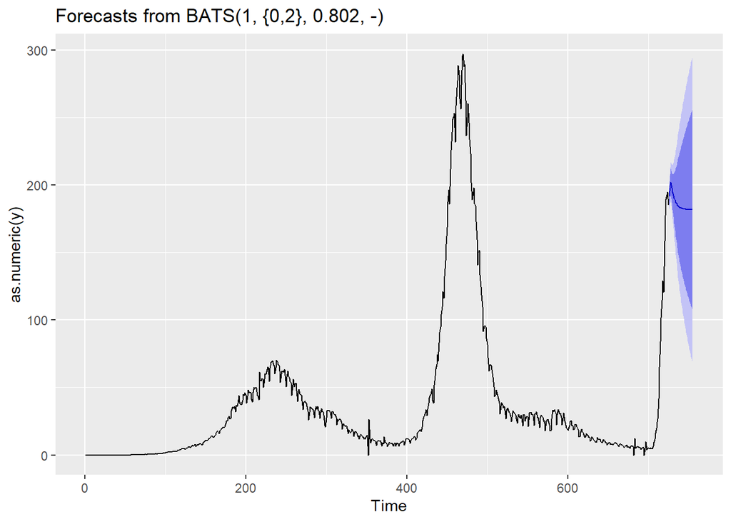

```r
autoplot(tbats.data)
```

## Observations

Facebook’s Prophet algorithm is widely used in time series forecasting. In our scenario, we observe that the model is good in predicting the lower half of the data, but, for sudden rise in data, it is not performing as expected. This can be fixed with changing the parameter seasonality.node=“multiplicative” in the model parameters. But then the model exhibits over-fitting nature. At the present we forecast number of new cases in upcoming 30 days. We observe a new wave of cases in this upcoming 30 days as displayed in the plot.